# 5073_HW3_Machine_Learning_Shuxiang_Sui

Unsupervised learning for red wine characteristics

```python
# Import packages
import pandas as pd
import numpy as np
import matplotlib.pyplot as plt
import seaborn as sns

# Import models
from sklearn.preprocessing import scale
from sklearn.cluster import KMeans
from scipy.stats import pearsonr
from scipy.spatial.distance import pdist
from scipy.cluster.hierarchy import linkage
from scipy.cluster.hierarchy import dendrogram
from sklearn.decomposition import PCA
from sklearn.cluster import AgglomerativeClustering
```

```python
#import the red wine file:
dfr = pd.read_csv("https://archive.ics.uci.edu/ml/machine-learning-databases/wine-quality/winequality-red.csv", sep = ";")
dfr.head()
```

|  | fixed acidity | volatile acidity | citric acid | residual sugar | chlorides | free sulfur dioxide | total sulfur dioxide | density | pH | sulphates | alcohol | quality |
| --- | --- | --- | --- | --- | --- | --- | --- | --- | --- | --- | --- | --- |
| 0 | 7.4 | 0.70 | 0.00 | 1.9 | 0.076 | 11.0 | 34.0 | 0.9978 | 3.51 | 0.56 | 9.4 | 5 |
| 1 | 7.8 | 0.88 | 0.00 | 2.6 | 0.098 | 25.0 | 67.0 | 0.9968 | 3.20 | 0.68 | 9.8 | 5 |
| 2 | 7.8 | 0.76 | 0.04 | 2.3 | 0.092 | 15.0 | 54.0 | 0.9970 | 3.26 | 0.65 | 9.8 | 5 |
| 3 | 11.2 | 0.28 | 0.56 | 1.9 | 0.075 | 17.0 | 60.0 | 0.9980 | 3.16 | 0.58 | 9.8 | 6 |
| 4 | 7.4 | 0.70 | 0.00 | 1.9 | 0.076 | 11.0 | 34.0 | 0.9978 | 3.51 | 0.56 | 9.4 | 5 |

1. Use K Means Cluster Analysis to identify cluster(s) of observations that have high and low values of the wine quality. (Assume all variables are continuous.)

```python
#scale the data with standard scaler
dfr_scaled=pd.DataFrame(scale(dfr), index=dfr.index, columns=dfr.columns)
dfr_scaled.head()
```

|  | fixed acidity | volatile acidity | citric acid | residual sugar | chlorides | free sulfur dioxide | total sulfur dioxide | density | pH | sulphates | alcohol | quality |
| --- | --- | --- | --- | --- | --- | --- | --- | --- | --- | --- | --- | --- |
| 0 | -0.528360 | 0.961877 | -1.391472 | -0.453218 | -0.243707 | -0.466193 | -0.379133 | 0.558274 | 1.288643 | -0.579207 | -0.960246 | -0.787823 |
| 1 | -0.298547 | 1.967442 | -1.391472 | 0.043416 | 0.223875 | 0.872638 | 0.624363 | 0.028261 | -0.719933 | 0.128950 | -0.584777 | -0.787823 |
| 2 | -0.298547 | 1.297065 | -1.186070 | -0.169427 | 0.096353 | -0.083669 | 0.229047 | 0.134264 | -0.331177 | -0.048089 | -0.584777 | -0.787823 |
| 3 | 1.654856 | -1.384443 | 1.484154 | -0.453218 | -0.264960 | 0.107592 | 0.411500 | 0.664277 | -0.979104 | -0.461180 | -0.584777 | 0.450848 |
| 4 | -0.528360 | 0.961877 | -1.391472 | -0.453218 | -0.243707 | -0.466193 | -0.379133 | 0.558274 | 1.288643 | -0.579207 | -0.960246 | -0.787823 |

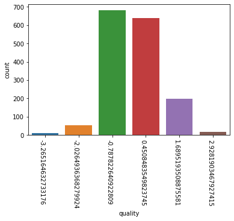

```python
#study the quality before we identify clusters:
plt.figure()
chart = sns.countplot(x = 'quality', data = dfr_scaled)
plt.xticks(rotation = -90, horizontalalignment = 'right')
plt.show()
```

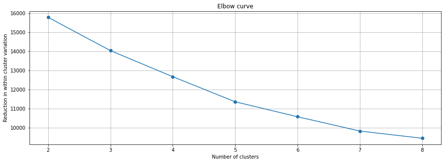

```python
# Create initiate empty list
within_cluster_variance = []

# build models for k from the range 2 to 9
for k in range(2, 9):
    kmeans = KMeans(n_clusters=k)
    kmeans.fit(dfr_scaled)
    within_cluster_variance.append(kmeans.inertia_)

#this could visualize the best cluster that we could find:
fig = plt.figure(figsize=(15, 5))
plt.plot(range(2, 9), within_cluster_variance, marker='o')
plt.grid(True)
plt.xlabel('Number of clusters')
plt.ylabel('Reduction in within cluster variation')
plt.title('Elbow curve');
```

```python
#test of the clusters n=7
kmeans = KMeans(n_clusters=7, random_state=42)
kmeans.fit(dfr_scaled)
dfr_scaled['cluster'] = kmeans.labels_
# sort by descending order of wine quality, compare the mean of each column.
dfr_c7 = dfr_scaled.groupby('cluster').mean().sort_values('quality', ascending=False)
print(dfr_c7)
```

```
         fixed acidity  volatile acidity  citric acid  residual sugar  \
cluster
6             0.330277         -0.994062     0.806363       -0.106281
0            -1.060821          0.224950    -0.833632       -0.259372
1             1.780258         -0.526463     1.251348        0.156319
5            -0.085633         -0.034652     0.414856        4.961768
3             0.081831          0.017955     1.144178       -0.399396
4            -0.153130          0.045000     0.012687       -0.030538
2            -0.435056          0.684676    -0.788310       -0.200857

         chlorides  free sulfur dioxide  total sulfur dioxide   density  \
cluster
6        -0.213323            -0.370890             -0.547897 -0.407516
0        -0.421750             0.087212             -0.243040 -1.364053
1         0.060692            -0.477687             -0.414366  1.295427
5         0.296388             1.750191              1.695832  1.225001
3         5.604731            -0.070479              0.474416  0.185803
4        -0.048821             1.038101              1.191052  0.158758
2        -0.057397            -0.467244             -0.405893 -0.008957

               pH  sulphates   alcohol   quality
cluster
6       -0.271505   0.457680  0.937421  0.974410
0        1.110905  -0.116131  1.271879  0.599760
1       -1.072556   0.242721 -0.167489  0.075674
5       -0.325460  -0.023789 -0.363913 -0.022761
3       -1.687357   3.720608 -0.882563 -0.360695
4       -0.046381  -0.159947 -0.524630 -0.399426
2        0.350443  -0.425773 -0.494039 -0.512838
```

```python
#test of the clusters n=5
kmeans = KMeans(n_clusters=5, random_state=6711)
kmeans.fit(dfr_scaled)
dfr_scaled['cluster'] = kmeans.labels_
# sort by descending order of wine quality, compare the mean of each column.
dfr_c5 = dfr_scaled.groupby('cluster').mean().sort_values('quality', ascending=False)
print(dfr_c5)
```

```
         fixed acidity  volatile acidity  citric acid  residual sugar  \
cluster
1            -0.197613         -0.523810     0.175417       -0.161395
2             1.783917         -0.526906     1.273046        0.202792
3             0.161077          0.046493     1.085087        0.803571
4            -0.164969          0.044453     0.012820        0.011884
0            -0.425497          0.656339    -0.749592        0.005009

         chlorides  free sulfur dioxide  total sulfur dioxide   density  \
cluster
1        -0.292719            -0.197544             -0.431089 -0.764426
2         0.063600            -0.450023             -0.399846  1.303520
3         5.050899             0.517438              0.689525  0.617485
4        -0.057441             1.056595              1.220548  0.134219
0        -0.057001            -0.405964             -0.336794  0.047831

               pH  sulphates   alcohol   quality
cluster
1        0.254675   0.231141  1.058916  0.832577
2       -1.083649   0.262086 -0.150962  0.079845
3       -1.519661   3.216177 -0.949518 -0.363135
4       -0.050228  -0.171361 -0.500992 -0.385255
0        0.334818  -0.414197 -0.500507 -0.504358
```

# Describe variables that cluster with higher values of wine quality. Describe variables that cluster with lower values of wine quality.

Since the clusters n=5 might be more representitive than n=7 clusters due to the high quality wine is very different to low quality wine.

And I will mostly focus on TOP 1 clusters from n=5 and n=7 for high quality, and bottom 1 or 2 clusters when n=5 for low quality.

**variables that cluster with higher values of wine quality:**

> Low volatile acidity

> Relative Low residual sugar

> Low chlorides

> Low total sulfur dioxide

> Low density

> Medium sulphates(neither high or low is the best)

> High alcohol!

**variables that cluster with lower values of wine quality:**

> Low fixed acidity

> High volatile acidity

> Low citric acid

> Low residual sugar

> Medium chlorides

> Low free sulfur dioxide

> Low total sulfur dioxide

> Medium density

> Medium-High pH

> Low sulphates

> Low alcohol

**My conclusion is: It seems like there are some variables are double-edged swords for us in producing high quality red wine, some may cause high quality but also result into a low quality red wine too.**

# 2. Use Hierarchical Cluster Analysis to identify cluster(s) of observations that have high and low values of the wine quality. (Assume all variables are continuous.) Use complete linkage and the same number of groups that you found to be the most meaningful in question 1.

Describe variables that cluster with higher values of wine quality. Describe variables that cluster with lower values of wine quality.

If you want to make a good bottle of wine, then what characteristics are most important according to this analysis? Have your conclusions changed using Hierarchical clustering rather than k means clustering? Present any figures that assist you in your analysis.

```python
#Use Hierarchical Cluster Analysis
## Refresh the data
dfr_hi=pd.DataFrame(scale(dfr), index=dfr.index, columns=dfr.columns)
# distance matrix for hierarchical clustering
# define distance metric and linkage for model
row_clusters = linkage(pdist(dfr, metric='euclidean'), method='complete')
```

```python
#define Agglomerative Clustering when n=5
np.random.RandomState(6711)
ac = AgglomerativeClustering(n_clusters=5,
                             affinity='euclidean',
                             linkage='complete')
dfr_hi['cluster'] = ac.fit_predict(dfr_hi)
# Show the mean values of each column for each
dfr_2 = dfr_hi.groupby('cluster').mean().sort_values('quality', ascending=False)
dfr_2
```

| cluster | fixed acidity | volatile acidity | citric acid | residual sugar | chlorides | free sulfur dioxide | total sulfur dioxide | density | pH | sulphates | alcohol | quality |
| --- | --- | --- | --- | --- | --- | --- | --- | --- | --- | --- | --- | --- |
| 4 | -0.624115 | -1.291336 | 1.364336 | 5.293553 | -0.675866 | 3.167777 | 5.956069 | -1.185471 | -1.259873 | -0.815259 | 1.136122 | 1.276629 |
| 0 | 1.117620 | -0.349720 | 1.004432 | -0.095057 | 1.470947 | -0.269898 | 0.035390 | 0.800639 | -1.292270 | 1.717645 | -0.341875 | 0.114017 |
| 2 | 0.284822 | -0.598039 | 0.630946 | 6.832574 | 0.639140 | 0.982981 | 0.505067 | 1.903286 | -0.500635 | 0.115332 | -0.599218 | 0.069719 |
| 1 | -0.088200 | 0.035595 | -0.090699 | -0.064045 | -0.133744 | 0.005247 | -0.019843 | -0.077709 | 0.111066 | -0.140651 | 0.030863 | -0.010170 |
| 3 | 0.074897 | -0.350945 | 3.127368 | 0.043416 | 11.116408 | 0.394484 | 0.320274 | 0.770280 | -2.663717 | 5.735193 | -0.960246 | -1.407158 |

We have a very perfect cluster that is different from others for the Top & Bottom quality red wine.

**Therefore, this time, we only summrize the good/bad quality red wine from best cluster and worst cluster.**

**variables that cluster with higher values of wine quality:**

> Low fixed acidity

> Low volatile acidity

> Medium-High citric acid

> High residual sugar [very different than q1]

> Low chlorides

> Very High free sulfur dioxide

> Very High total sulfur dioxide [very different than q1]

> Low density

> Medium-Low pH

> Low sulphates

> High alcohol!

**variables that cluster with lower values of wine quality:**

> Medium fixed acidity

> Very High citric acid [very different than q1]

> Medium residual sugar

> Super Super high chlorides [very different than q1]

> Medium free sulfur dioxide

> Medium total sulfur dioxide

> Medium density

> Low pH [very different than q1]

> Very High sulphates [very different than q1]

> Low alcohol

**My conclusion is: It seems like there are lots lots of changes in the key factors of making a best/worst red wine as we could observe from some variables. Such as the citric acid, chlorides, pH value and Sulphates change very much for low quality red wine, and also for High quality red wine, amount of residual sugar and total sulfur dioxide change hugely for the standard of the best red wine.**

If you want to make a good bottle of wine, then what characteristics are most important according to this analysis?

Have your conclusions changed using Hierarchical clustering rather than k means clustering?

Present any figures that assist you in your analysis.

**For making a good bottle of red wine, I believe Low volatile acidity, Low chlorides, low density and High alcohol should be important characteristics!**

**There are many changes while using Hierarchical clustering.**

Firstly, conclusions made for Residual sugar and Total sulfur dioxide change hugely, they all switch from low to High or Very high, and this might be due to the K Mean and Hierarchical are differtiate the clusters by different logic, and this let them push some of the wine into top1 cluster and some not.

**But for both of K menas and Hierarchical clustering, when n=5, Hierarchical clustering gives us a better wine quality score after scaling, therefore I do believe the Hierarchical clustering has more credentials in this analysis.**

# 3. Use Principal Components Analysis to reduce the dimensions of your data. How much of the variation in your data is explained by the first two principal components. How might you use the first two components to do supervised learning on some other variable tied to wine (e.g. - wine price)?

```python
# How much of the variation in your data is explained by the first two principal
X=pd.DataFrame(scale(dfr), index=dfr.index, columns=dfr.columns)
X_pca = PCA(n_components=3, random_state=6711)
X_pca.fit(X)
print(X_pca.explained_variance_ratio_)
sum(X_pca.explained_variance_ratio_[0:2])
```

```
[0.26009731 0.1868235  0.14024331]
```

```
0.4469208117069173
```

the first two principals explained 44.69% of the variations.

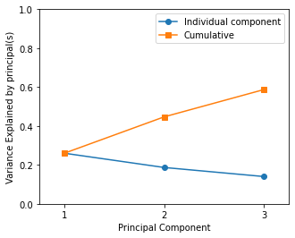

```python
plt.figure(figsize=(5,4))

plt.plot([1,2,3], X_pca.explained_variance_ratio_, '-o', label='Individual component')
plt.plot([1,2,3], np.cumsum(X_pca.explained_variance_ratio_), '-s', label='Cumulative')

plt.ylabel('Variance Explained by principal(s)')
plt.xlabel('Principal Component')
plt.xlim(0.75,3.25)
plt.ylim(0,1)
plt.xticks([1,2,3])
plt.legend(loc=1);
```

```python
#from descending orders, check the important factors for the first principal component.
pca_loadings = pd.DataFrame(X_pca.fit(X).components_.T, index=X.columns, columns=['V1', 'V2', 'V3'])
pca_loadings.sort_values('V1', ascending=False)
```

|  | V1 | V2 | V3 |
| --- | --- | --- | --- |
| fixed acidity | 0.487883 | -0.004173 | -0.164829 |
| citric acid | 0.473335 | -0.137358 | 0.100229 |
| density | 0.370301 | 0.330781 | -0.168723 |
| sulphates | 0.254535 | -0.109334 | 0.212913 |
| chlorides | 0.197427 | 0.189788 | -0.026608 |
| residual sugar | 0.139154 | 0.167736 | 0.243620 |
| quality | 0.112489 | -0.473166 | 0.223369 |
| total sulfur dioxide | 0.004067 | 0.363971 | 0.540732 |
| free sulfur dioxide | -0.045881 | 0.259483 | 0.616111 |
| alcohol | -0.073177 | -0.502709 | 0.224971 |
| volatile acidity | -0.265129 | 0.338968 | -0.227089 |
| pH | -0.432721 | -0.065440 | 0.069771 |

```python
#from descending orders, check the important factors for the second principal component.
pca_loadings.sort_values('V2', ascending=False)
```

|  | V1 | V2 | V3 |
| --- | --- | --- | --- |
| total sulfur dioxide | 0.004067 | 0.363971 | 0.540732 |
| volatile acidity | -0.265129 | 0.338968 | -0.227089 |
| density | 0.370301 | 0.330781 | -0.168723 |
| free sulfur dioxide | -0.045881 | 0.259483 | 0.616111 |
| chlorides | 0.197427 | 0.189788 | -0.026608 |
| residual sugar | 0.139154 | 0.167736 | 0.243620 |
| fixed acidity | 0.487883 | -0.004173 | -0.164829 |
| pH | -0.432721 | -0.065440 | 0.069771 |
| sulphates | 0.254535 | -0.109334 | 0.212913 |
| citric acid | 0.473335 | -0.137358 | 0.100229 |
| quality | 0.112489 | -0.473166 | 0.223369 |
| alcohol | -0.073177 | -0.502709 | 0.224971 |

How might you use the first two components to do supervised learning on some other variable tied to wine (e.g. - wine price)?

As we analyze the first two components, we could find out the specific terms inside each of the components, and find those variables with greatest correlations, and then use these varibles with the new variable such as wine price to complete the supervised learning, and this could also let us add more variables such as the materials of the wine in that year, or the water sulfer oxide, the acidity for grapes or materials such as citric acid. By combining all of these, and import the model and train the data with gridsearchCV with these reasonable variable in the components, we might simulate the wine price for the year before the wine is producted.